# Rupesh Singh - Ensemble Techniques

#### Multivariate analysis (8 marks)

a. Bi-variate analysis between the predictor variables and target column. Comment on your findings in terms of their relationship and degree of relation if any. Visualize the analysis using boxplots and pair plots, histograms or density curves. Select the most appropriate attributes.  
b. Please provide comments in jupyter notebook regarding the steps you take and insights drawn from the plots

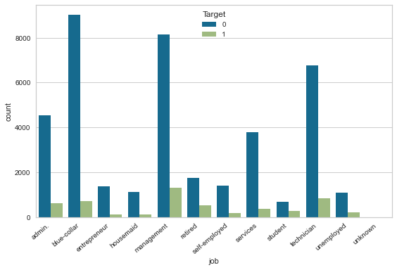

```python
ax = sns.countplot(x="job", hue="Target", data=data)
ax.set_xticklabels(ax.get_xticklabels(), rotation=40, ha="right")
plt.tight_layout()
plt.show()

# management job is subscribing the most, followed by technician, blue-collar and admin
```

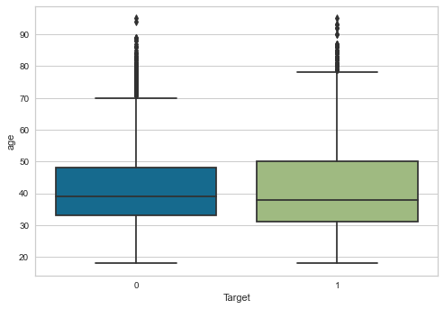

```python
sns.boxplot(data=data,y="age",x="Target")
plt.show()

# People with the age range ~31 to ~50 are likely to subscribe most for the term deposit
```

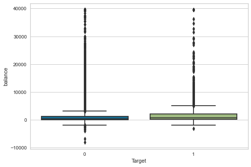

```python
sns.boxplot(data=data,y="balance",x="Target",saturation=0.75, width=0.8, dodge=True, fliersize=5, linewidth=None, whis=1.5, ax=None)
plt.show()
```

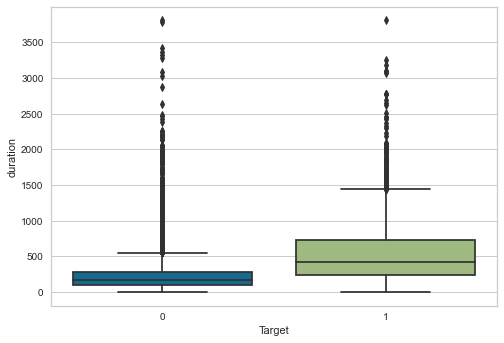

```python
sns.boxplot(data=data,y="duration",x="Target")
plt.show()

# people with call duration 200s to 700s are likely to subscribe
```

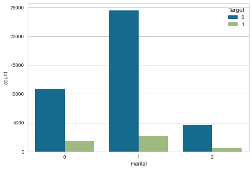

```python
sns.countplot(x="marital", hue="Target", data=data)
plt.show()

# married people are subscribing the most and divorced the least
```

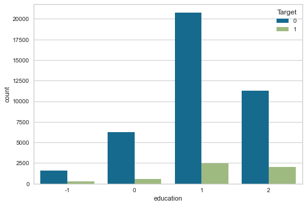

```python
sns.countplot(x="education", hue="Target", data=data)
plt.show()

# People helding upto or above secondary education are subscribing the most
```

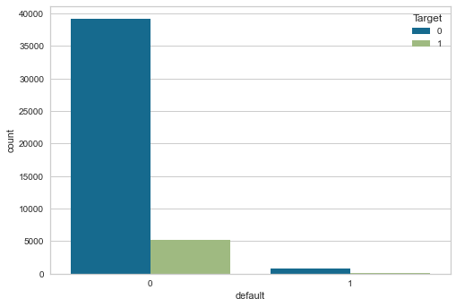

```python
sns.countplot(x="default", hue="Target", data=data)
plt.show()

# People with NO credit are subscribing
```

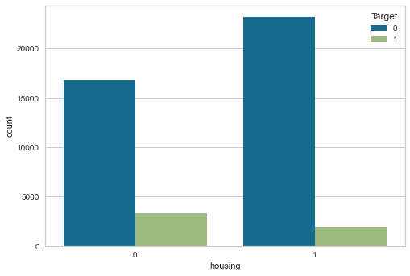

```python
sns.countplot(x="housing", hue="Target", data=data)
plt.show()
```

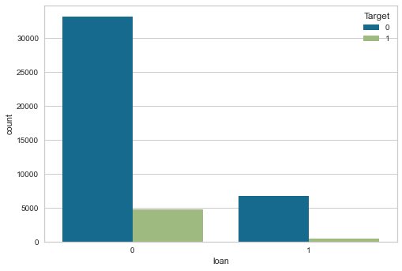

```python
sns.countplot(x="loan", hue="Target", data=data)
plt.show()

# People having no personal loan are subscribing the most
```

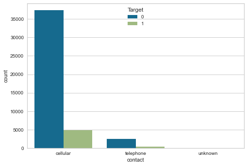

```python
sns.countplot(x="contact", hue="Target", data=data)
plt.show()
```

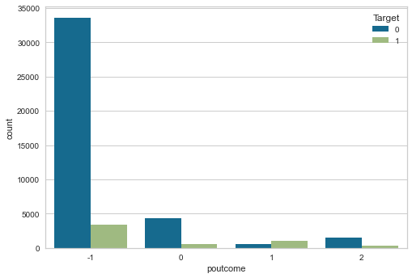

```python
sns.countplot(x="poutcome", hue="Target", data=data)
plt.show()
```

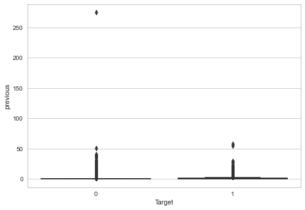

```python
sns.boxplot(y="previous", x="Target", data=data)
```

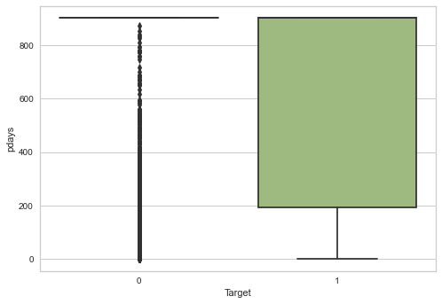

```python
sns.boxplot(y="pdays", x="Target", data=data)
```

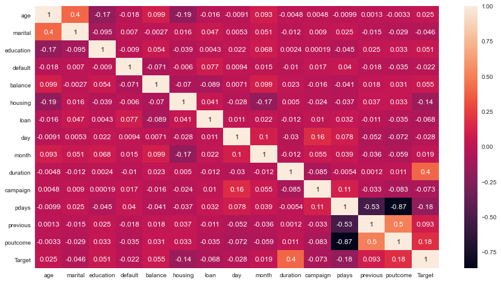

```python
# Plotting the heatmap

plt.figure(figsize=(15,8))
sns.heatmap(data.corr(),annot=True)
plt.show()

# Call duration & previous marketing campain outcome seems to contribute much for the term subscription
```

```python
# Drawing Pairplot - It got hang so commenting it

#sns.pairplot(data,diag_kind='kde')
#plt.show()
```

## Deliverable – 2 (Prepare the data for analytics) – (10)

1. Ensure the attribute types are correct. If not, take appropriate actions.
2. Get the data model ready.
3. Transform the data i.e. scale / normalize if required.
4. Create the training set and test set in ratio of 70:30.

```python
# Convert data to categorical values

labelencoder_X=LabelEncoder()
data['job']=labelencoder_X.fit_transform(data['job'])
data['contact']=labelencoder_X.fit_transform(data['contact'])
```

```python
# In the above sections, attributes were changed into category
# Now splitting the independent and dependent variables

X=data.loc[:,data.columns!='Target']
y=data.loc[:,data.columns=='Target']

# Split X and y into training and test set in 70:30 ratio
x_train,x_test,y_train,y_test=train_test_split(X,y,test_size=0.3,random_state=7)
columns=x_train.columns

# Packages for normalization
from sklearn.preprocessing import StandardScaler
scaler=StandardScaler()
scaler.fit(x_train)
x_train = scaler.transform(x_train)
x_test = scaler.transform(x_test)
```

### Deliverable – 3 (create the ensemble model) – (30)

1. First create models using Logistic Regression and Decision Tree algorithm. Note the model performance by using different matrices. Use confusion matrix to evaluate class level metrics i.e. Precision/Recall. Also reflect the accuracy and F1 score of the model. (10 marks)
2. Build the ensemble models (Bagging and Boosting) and note the model performance by using different matrices. Use same metrics as in above model. (at least 3 algorithms) (15 marks)
3. Make a DataFrame to compare models and their metrics. Give conclusion regarding the best algorithm and your reason behind it. (5 marks)

```python
# Importing useful libraries
from sklearn.model_selection import train_test_split
from sklearn.linear_model import LogisticRegression
from sklearn.metrics import roc_curve,auc
from sklearn.metrics import recall_score,classification_report, precision_score, f1_score, accuracy_score, confusion_matrix
from sklearn.metrics import roc_auc_score
from sklearn.metrics import roc_curve

## defining a function to get confusion matrix in a proper format
def draw_confusion_matrix( actual, predicted ):
    cm = confusion_matrix( actual, predicted)
    sns.heatmap(cm, annot=True,  fmt='.2f', xticklabels = [0,1] , yticklabels = [0,1] )
    plt.ylabel('Observed')
    plt.xlabel('Predicted')
    plt.show()

# defining a function to print out model results
def print_results(regression_model, x_test, y_test, y_predict):
    print("Training accuracy:",regression_model.score(x_train,y_train))
    print()
    print("Testing Accuracy:",regression_model.score(x_test, y_test))
    print()
    print("Recall:",recall_score(y_test,y_predict))
    print()
    print("Precision:",precision_score(y_test,y_predict))
    print()
    print("F1 Score:",f1_score(y_test,y_predict))
    print()
    print("Roc Auc Score:",roc_auc_score(y_test,y_predict))
    print()
    print('Confusion Matrix')
    print(draw_confusion_matrix(y_test,y_predict))

# defining a function to draw area under the curve
def draw_curve(regression_model,y_test,x_test):
    logit_roc_auc = roc_auc_score(y_test, regression_model.predict(x_test))
    fpr, tpr, thresholds = roc_curve(y_test, regression_model.predict_proba(x_test)[:,1])
    plt.figure()
    plt.plot(fpr, tpr, label='Logistic Regression (area = %0.2f)' % logit_roc_auc)
    plt.plot([0, 1], [0, 1],'r--')
    plt.xlim([0.0, 1.0])
    plt.ylim([0.0, 1.05])
    plt.xlabel('False Positive Rate')
    plt.ylabel('True Positive Rate')
    plt.title('Receiver operating characteristic')
    plt.legend(loc="lower right")
    plt.savefig('Log_ROC')
    plt.show()
```

```
Training accuracy: 0.8900053717571966

Testing Accuracy: 0.8969330580949573

Recall: 0.2438070404172099

Precision: 0.6111111111111112

F1 Score: 0.34855545200372784

Roc Auc Score: 0.6120115833839999

Confusion Matrix
```

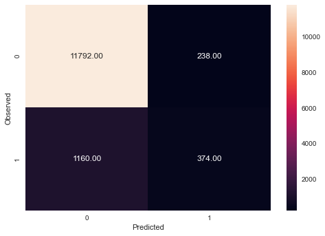

```
None
```

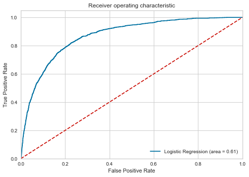

|  | Method | Training accuracy | Testing accuracy | F1 score | Recall | Precision | Roc Auc Score |
| --- | --- | --- | --- | --- | --- | --- | --- |
| 0 | Logistic Regression | 0.890005 | 0.896933 | 0.348555 | 0.243807 | 0.611111 | 0.612012 |

```python
# Fit the model on train
model = LogisticRegression()
model.fit(x_train, y_train)

# Predict on test
y_predict = model.predict(x_test)

print_results(model, x_test, y_test, y_predict)

draw_curve(model,y_test,x_test)


# Store the accuracy results for each model in a dataframe for final comparison
results = pd.DataFrame({'Method':['Logistic Regression'], 'Training accuracy': model.score(x_train,y_train),
                        'Testing accuracy': model.score(x_test, y_test),
                       'F1 score': f1_score(y_test, y_predict),'Recall': recall_score(y_test, y_predict),
                       'Precision': precision_score(y_test, y_predict), 'Roc Auc Score': roc_auc_score(y_test,y_predict)})
results = results[['Method', 'Training accuracy','Testing accuracy','F1 score','Recall','Precision','Roc Auc Score']]
results
```

```
Training accuracy: 1.0

Testing Accuracy: 0.8709820112061338

Recall: 0.46740547588005216

Precision: 0.43454545454545457

F1 Score: 0.4503768844221106

Roc Auc Score: 0.6949246830771831

Confusion Matrix
```

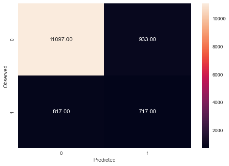

```
None
```

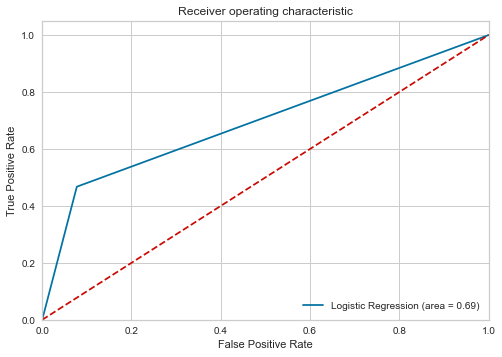

|  | Method | Training accuracy | Testing accuracy | F1 score | Recall | Precision | Roc Auc Score |
| --- | --- | --- | --- | --- | --- | --- | --- |
| 0 | Logistic Regression | 0.890005 | 0.896933 | 0.348555 | 0.243807 | 0.611111 | 0.612012 |
| 0 | DecisionTree Classifier | 1.000000 | 0.870982 | 0.450377 | 0.467405 | 0.434545 | 0.694925 |

```python
# Decision Tree Classifier
from sklearn import metrics
from sklearn.tree import DecisionTreeClassifier

# Fit the model on train
model = DecisionTreeClassifier()
model.fit(x_train, y_train)

# Predict on test
y_predict = model.predict(x_test)

print_results(model, x_test, y_test, y_predict)

draw_curve(model,y_test,x_test)

# Store the accuracy results for each model in a dataframe for final comparison
resultsnew = pd.DataFrame({'Method':['DecisionTree Classifier'], 'Training accuracy': model.score(x_train,y_train),
                        'Testing accuracy': model.score(x_test, y_test),
                       'F1 score': f1_score(y_test, y_predict),'Recall': recall_score(y_test, y_predict),
                       'Precision': precision_score(y_test, y_predict), 'Roc Auc Score': roc_auc_score(y_test,y_predict)})
results = pd.concat([results, resultsnew])
results = results[['Method', 'Training accuracy','Testing accuracy','F1 score','Recall','Precision','Roc Auc Score']]
results
```

```
Training accuracy: 0.920655986349417

Testing Accuracy: 0.8984812739604836

Recall: 0.4361147327249022

Precision: 0.5664690939881456

F1 Score: 0.49281767955801103

Roc Auc Score: 0.6967772333616199

Confusion Matrix
```

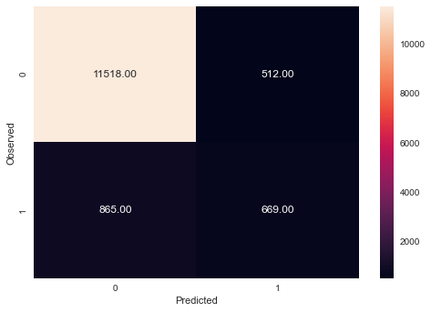

```
None
```

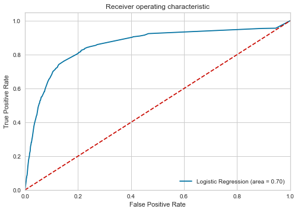

|  | Method | Training accuracy | Testing accuracy | F1 score | Recall | Precision | Roc Auc Score |
| --- | --- | --- | --- | --- | --- | --- | --- |
| 0 | Logistic Regression | 0.890005 | 0.896933 | 0.348555 | 0.243807 | 0.611111 | 0.612012 |
| 0 | DecisionTree Classifier | 1.000000 | 0.870982 | 0.450377 | 0.467405 | 0.434545 | 0.694925 |
| 0 | Pruned Decision Tree Classifier | 0.920656 | 0.898481 | 0.492818 | 0.436115 | 0.566469 | 0.696777 |

```python
# Pruned Decision Tree Classifier
from sklearn import metrics
from sklearn.tree import DecisionTreeClassifier

# Fit the model on train
model = DecisionTreeClassifier( max_depth = 10,random_state=100,min_samples_leaf=5)
model.fit(x_train, y_train)

# Predict on test
y_predict = model.predict(x_test)

print_results(model, x_test, y_test, y_predict)

draw_curve(model,y_test,x_test)

resultsnew = pd.DataFrame({'Method':['Pruned Decision Tree Classifier'], 'Training accuracy': model.score(x_train,y_train),
                        'Testing accuracy': model.score(x_test, y_test),
                       'F1 score': f1_score(y_test, y_predict),'Recall': recall_score(y_test, y_predict),
                       'Precision': precision_score(y_test, y_predict), 'Roc Auc Score': roc_auc_score(y_test,y_predict)})
results = pd.concat([results, resultsnew])
results = results[['Method', 'Training accuracy','Testing accuracy','F1 score','Recall','Precision','Roc Auc Score']]
results
```

##### Bagging: Random Forest Classifier, Bagging

##### Boosting: AdaBoosting, GradientBoost, XGBoost

```
Training accuracy: 0.9999684014282555

Testing Accuracy: 0.9051902093777646

Recall: 0.3917861799217731

Precision: 0.629979035639413

F1 Score: 0.4831189710610933

Roc Auc Score: 0.6812214357630478

Confusion Matrix
```

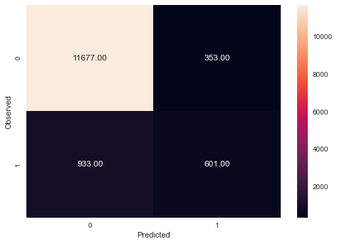

```
None
```

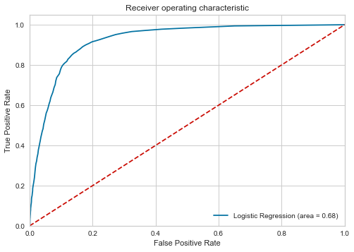

|  | Method | Training accuracy | Testing accuracy | F1 score | Recall | Precision | Roc Auc Score |
| --- | --- | --- | --- | --- | --- | --- | --- |
| 0 | Logistic Regression | 0.890005 | 0.896933 | 0.348555 | 0.243807 | 0.611111 | 0.612012 |
| 0 | DecisionTree Classifier | 1.000000 | 0.870982 | 0.450377 | 0.467405 | 0.434545 | 0.694925 |
| 0 | Pruned Decision Tree Classifier | 0.920656 | 0.898481 | 0.492818 | 0.436115 | 0.566469 | 0.696777 |
| 0 | Random Forest Classifier | 0.999968 | 0.905190 | 0.483119 | 0.391786 | 0.629979 | 0.681221 |

```python
# Random Forest Classifier
from sklearn import metrics
from sklearn.ensemble import RandomForestClassifier

# Fit the model on train
model = RandomForestClassifier()
model.fit(x_train, y_train)

# Predict on test
y_predict = model.predict(x_test)

print_results(model, x_test, y_test, y_predict)

draw_curve(model,y_test,x_test)


resultsnew = pd.DataFrame({'Method':['Random Forest Classifier'], 'Training accuracy': model.score(x_train,y_train),
                        'Testing accuracy': model.score(x_test, y_test),
                       'F1 score': f1_score(y_test, y_predict),'Recall': recall_score(y_test, y_predict),
                       'Precision': precision_score(y_test, y_predict), 'Roc Auc Score': roc_auc_score(y_test,y_predict)})
results = pd.concat([results, resultsnew])
results = results[['Method', 'Training accuracy','Testing accuracy','F1 score','Recall','Precision','Roc Auc Score']]
results
```

```
Training accuracy: 0.9996840142825544

Testing Accuracy: 0.9056325567679151

Recall: 0.3917861799217731

Precision: 0.6339662447257384

F1 Score: 0.4842868654311039

Roc Auc Score: 0.6814708123216513

Confusion Matrix
```

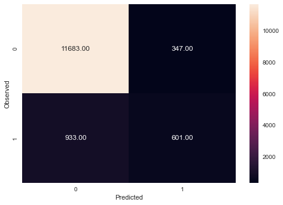

```
None
```

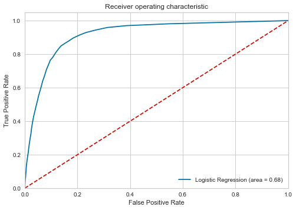

|  | Method | Training accuracy | Testing accuracy | F1 score | Recall | Precision | Roc Auc Score |
| --- | --- | --- | --- | --- | --- | --- | --- |
| 0 | Logistic Regression | 0.890005 | 0.896933 | 0.348555 | 0.243807 | 0.611111 | 0.612012 |
| 0 | DecisionTree Classifier | 1.000000 | 0.870982 | 0.450377 | 0.467405 | 0.434545 | 0.694925 |
| 0 | Pruned Decision Tree Classifier | 0.920656 | 0.898481 | 0.492818 | 0.436115 | 0.566469 | 0.696777 |
| 0 | Random Forest Classifier | 0.999968 | 0.905190 | 0.483119 | 0.391786 | 0.629979 | 0.681221 |
| 0 | Tuned RandomForest Classifier | 0.999684 | 0.905633 | 0.484287 | 0.391786 | 0.633966 | 0.681471 |

```python
# Tuned Random Forest Classifier

from sklearn import metrics
from sklearn.ensemble import RandomForestClassifier

# Fit the model on train
model = RandomForestClassifier(n_estimators = 50,random_state=100)
model.fit(x_train, y_train)

# Predict on test
y_predict = model.predict(x_test)

print_results(model, x_test, y_test, y_predict)

draw_curve(model,y_test,x_test)

resultsnew = pd.DataFrame({'Method':['Tuned RandomForest Classifier'], 'Training accuracy': model.score(x_train,y_train),
                        'Testing accuracy': model.score(x_test, y_test),
                       'F1 score': f1_score(y_test, y_predict),'Recall': recall_score(y_test, y_predict),
                       'Precision': precision_score(y_test, y_predict), 'Roc Auc Score': roc_auc_score(y_test,y_predict)})
results = pd.concat([results, resultsnew])
results = results[['Method', 'Training accuracy','Testing accuracy','F1 score','Recall','Precision','Roc Auc Score']]
results
```

```
Training accuracy: 0.9995892185673207

Testing Accuracy: 0.9031996461220879

Recall: 0.44198174706649285

Precision: 0.5973568281938326

F1 Score: 0.508055451479955

Roc Auc Score: 0.7019966923196138

Confusion Matrix
```

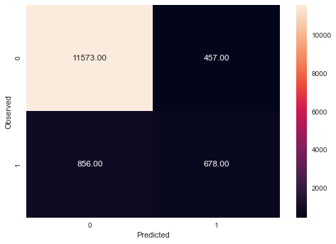

```
None
```

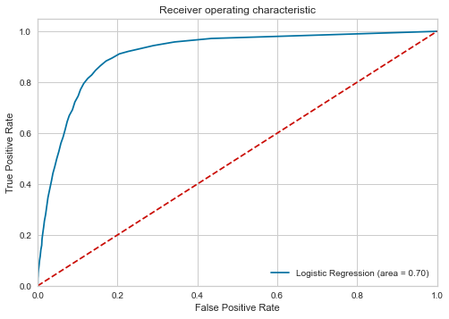

|  | Method | Training accuracy | Testing accuracy | F1 score | Recall | Precision | Roc Auc Score |
| --- | --- | --- | --- | --- | --- | --- | --- |
| 0 | Logistic Regression | 0.890005 | 0.896933 | 0.348555 | 0.243807 | 0.611111 | 0.612012 |
| 0 | DecisionTree Classifier | 1.000000 | 0.870982 | 0.450377 | 0.467405 | 0.434545 | 0.694925 |
| 0 | Pruned Decision Tree Classifier | 0.920656 | 0.898481 | 0.492818 | 0.436115 | 0.566469 | 0.696777 |
| 0 | Random Forest Classifier | 0.999968 | 0.905190 | 0.483119 | 0.391786 | 0.629979 | 0.681221 |
| 0 | Tuned RandomForest Classifier | 0.999684 | 0.905633 | 0.484287 | 0.391786 | 0.633966 | 0.681471 |
| 0 | Bagging Classifier | 0.999589 | 0.903200 | 0.508055 | 0.441982 | 0.597357 | 0.701997 |

```python
# Bagging Classifier
# We will restrict the number of estimators as without giving it may lead to overfitting
from sklearn import metrics
from sklearn.ensemble import BaggingClassifier

# Fit the model on train
model = BaggingClassifier(n_estimators=50,random_state=100)
model.fit(x_train, y_train)

# Predict on test
y_predict = model.predict(x_test)

print_results(model, x_test, y_test, y_predict)

draw_curve(model,y_test,x_test)

resultsnew = pd.DataFrame({'Method':['Bagging Classifier'], 'Training accuracy': model.score(x_train,y_train),
                        'Testing accuracy': model.score(x_test, y_test),
                       'F1 score': f1_score(y_test, y_predict),'Recall': recall_score(y_test, y_predict),
                       'Precision': precision_score(y_test, y_predict), 'Roc Auc Score': roc_auc_score(y_test,y_predict)})
results = pd.concat([results, resultsnew])
results = results[['Method', 'Training accuracy','Testing accuracy','F1 score','Recall','Precision','Roc Auc Score']]
results
```

```
Training accuracy: 0.8958827061016842

Testing Accuracy: 0.90002948982601

Recall: 0.34485006518904826

Precision: 0.6011363636363637

F1 Score: 0.4382767191383596

Roc Auc Score: 0.65783650391622

Confusion Matrix
```

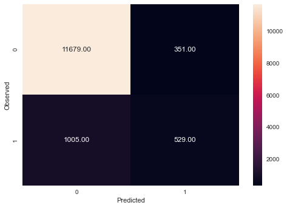

```
None
```

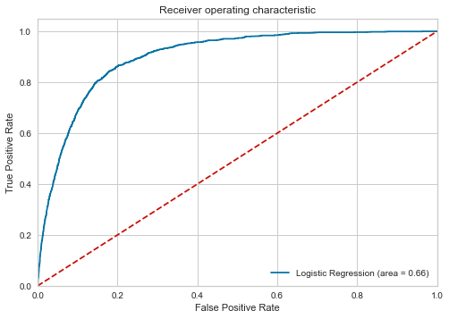

|  | Method | Training accuracy | Testing accuracy | F1 score | Recall | Precision | Roc Auc Score |
| --- | --- | --- | --- | --- | --- | --- | --- |
| 0 | Logistic Regression | 0.890005 | 0.896933 | 0.348555 | 0.243807 | 0.611111 | 0.612012 |
| 0 | DecisionTree Classifier | 1.000000 | 0.870982 | 0.450377 | 0.467405 | 0.434545 | 0.694925 |
| 0 | Pruned Decision Tree Classifier | 0.920656 | 0.898481 | 0.492818 | 0.436115 | 0.566469 | 0.696777 |
| 0 | Random Forest Classifier | 0.999968 | 0.905190 | 0.483119 | 0.391786 | 0.629979 | 0.681221 |
| 0 | Tuned RandomForest Classifier | 0.999684 | 0.905633 | 0.484287 | 0.391786 | 0.633966 | 0.681471 |
| 0 | Bagging Classifier | 0.999589 | 0.903200 | 0.508055 | 0.441982 | 0.597357 | 0.701997 |
| 0 | Ada Boosting Classifier | 0.895883 | 0.900029 | 0.438277 | 0.344850 | 0.601136 | 0.657837 |

```python
# Ada Boosting
from sklearn import metrics
from sklearn.ensemble import AdaBoostClassifier

# Fit the model on train
model = AdaBoostClassifier(n_estimators=50,random_state=100)
model.fit(x_train, y_train)

# Predict on test
y_predict = model.predict(x_test)

print_results(model, x_test, y_test, y_predict)

draw_curve(model,y_test,x_test)

resultsnew = pd.DataFrame({'Method':['Ada Boosting Classifier'], 'Training accuracy': model.score(x_train,y_train),
                        'Testing accuracy': model.score(x_test, y_test),
                       'F1 score': f1_score(y_test, y_predict),'Recall': recall_score(y_test, y_predict),
                       'Precision': precision_score(y_test, y_predict), 'Roc Auc Score': roc_auc_score(y_test,y_predict)})
results = pd.concat([results, resultsnew])
results = results[['Method', 'Training accuracy','Testing accuracy','F1 score','Recall','Precision','Roc Auc Score']]
results
```

```
Training accuracy: 0.902960786172465

Testing Accuracy: 0.9054113830728399

Recall: 0.35071707953063885

Precision: 0.6521212121212121

F1 Score: 0.45612547689699023

Roc Auc Score: 0.6634300277121191

Confusion Matrix
```

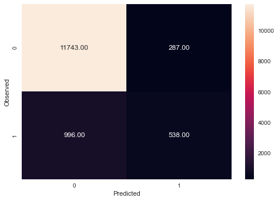

```
None
```

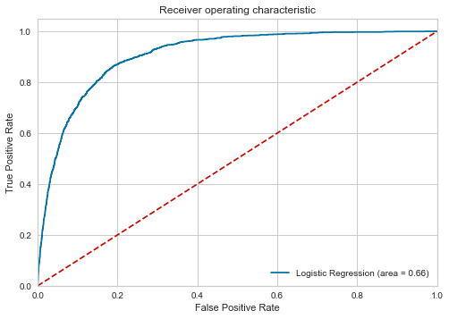

|  | Method | Training accuracy | Testing accuracy | F1 score | Recall | Precision | Roc Auc Score |
| --- | --- | --- | --- | --- | --- | --- | --- |
| 0 | Logistic Regression | 0.890005 | 0.896933 | 0.348555 | 0.243807 | 0.611111 | 0.612012 |
| 0 | DecisionTree Classifier | 1.000000 | 0.870982 | 0.450377 | 0.467405 | 0.434545 | 0.694925 |
| 0 | Pruned Decision Tree Classifier | 0.920656 | 0.898481 | 0.492818 | 0.436115 | 0.566469 | 0.696777 |
| 0 | Random Forest Classifier | 0.999968 | 0.905190 | 0.483119 | 0.391786 | 0.629979 | 0.681221 |
| 0 | Tuned RandomForest Classifier | 0.999684 | 0.905633 | 0.484287 | 0.391786 | 0.633966 | 0.681471 |
| 0 | Bagging Classifier | 0.999589 | 0.903200 | 0.508055 | 0.441982 | 0.597357 | 0.701997 |
| 0 | Ada Boosting Classifier | 0.895883 | 0.900029 | 0.438277 | 0.344850 | 0.601136 | 0.657837 |
| 0 | Gradient Boosting Classifier | 0.902961 | 0.905411 | 0.456125 | 0.350717 | 0.652121 | 0.663430 |

```python
# Gradient Boosting Classifier

from sklearn import metrics
from sklearn.ensemble import GradientBoostingClassifier

# Fit the model on train
model = GradientBoostingClassifier(n_estimators=50,random_state=100)
model.fit(x_train, y_train)

# Predict on test
y_predict = model.predict(x_test)

print_results(model, x_test, y_test, y_predict)

draw_curve(model,y_test,x_test)

resultsnew = pd.DataFrame({'Method':['Gradient Boosting Classifier'], 'Training accuracy': model.score(x_train,y_train),
                        'Testing accuracy': model.score(x_test, y_test),
                       'F1 score': f1_score(y_test, y_predict),'Recall': recall_score(y_test, y_predict),
                       'Precision': precision_score(y_test, y_predict), 'Roc Auc Score': roc_auc_score(y_test,y_predict)})
results = pd.concat([results, resultsnew])
results = results[['Method', 'Training accuracy','Testing accuracy','F1 score','Recall','Precision','Roc Auc Score']]
results
```

```python
! pip install xgboost
```

```
Training accuracy: 0.9550036338357506

Testing Accuracy: 0.9050427602477146

Recall: 0.4556714471968709

Precision: 0.6067708333333334

F1 Score: 0.5204765450483991

Roc Auc Score: 0.7090077934238719

Confusion Matrix
```

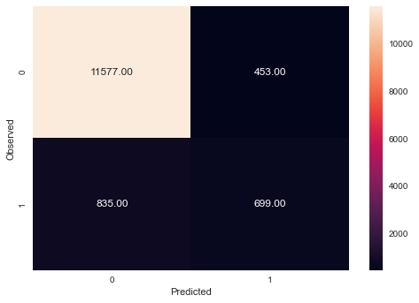

```
None
```

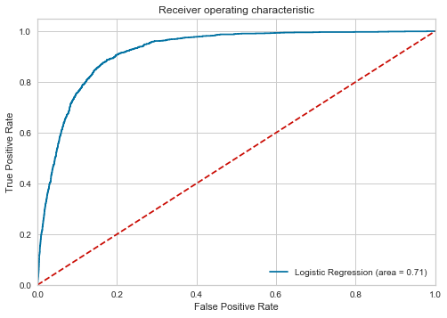

|  | Method | Training accuracy | Testing accuracy | F1 score | Recall | Precision | Roc Auc Score |
| --- | --- | --- | --- | --- | --- | --- | --- |
| 0 | Logistic Regression | 0.890005 | 0.896933 | 0.348555 | 0.243807 | 0.611111 | 0.612012 |
| 0 | DecisionTree Classifier | 1.000000 | 0.870982 | 0.450377 | 0.467405 | 0.434545 | 0.694925 |
| 0 | Pruned Decision Tree Classifier | 0.920656 | 0.898481 | 0.492818 | 0.436115 | 0.566469 | 0.696777 |
| 0 | Random Forest Classifier | 0.999968 | 0.905190 | 0.483119 | 0.391786 | 0.629979 | 0.681221 |
| 0 | Tuned RandomForest Classifier | 0.999684 | 0.905633 | 0.484287 | 0.391786 | 0.633966 | 0.681471 |
| 0 | Bagging Classifier | 0.999589 | 0.903200 | 0.508055 | 0.441982 | 0.597357 | 0.701997 |
| 0 | Ada Boosting Classifier | 0.895883 | 0.900029 | 0.438277 | 0.344850 | 0.601136 | 0.657837 |
| 0 | Gradient Boosting Classifier | 0.902961 | 0.905411 | 0.456125 | 0.350717 | 0.652121 | 0.663430 |
| 0 | XGBoost Classifier | 0.955004 | 0.905043 | 0.520477 | 0.455671 | 0.606771 | 0.709008 |

```python
# XG Boost

from sklearn import metrics
import xgboost as xgb

# Fit the model on train
model = xgb.XGBClassifier(objective="binary:logistic", random_state=42)
model.fit(x_train, y_train)

# Predict on test
y_predict = model.predict(x_test)

print_results(model, x_test, y_test, y_predict)

draw_curve(model,y_test,x_test)

resultsnew = pd.DataFrame({'Method':['XGBoost Classifier'], 'Training accuracy': model.score(x_train,y_train),
                        'Testing accuracy': model.score(x_test, y_test),
                       'F1 score': f1_score(y_test, y_predict),'Recall': recall_score(y_test, y_predict),
                       'Precision': precision_score(y_test, y_predict), 'Roc Auc Score': roc_auc_score(y_test,y_predict)})
results = pd.concat([results, resultsnew])
results = results[['Method', 'Training accuracy','Testing accuracy','F1 score','Recall','Precision','Roc Auc Score']]
results
```